# Covid19 Data Analysis

RB

2025-07-1

# COVID19 Data Analysis

## Dataset Overview

This analysis examines COVID-19 data from the Center for Systems Science and Engineering (CSSE) at Johns Hopkins University. The data collected information regarding confirmed case numbers globally and in the US, as well as death numbers.

You can access the data from [csse_covid_19_time_series file](https://github.com/CSSEGISandData/COVID-19/tree/master/csse_covid_19_data/csse_covid_19_time_series).

## Research Questions

1. What were the trends in confirmed cases and deaths in the United States over time?
2. Which countries have the highest confirmed cases and deaths per capita?
3. Which US States were affected the most and which were affected the least relative to their population?
4. Was there a correlation between case rates and death rates within the United States?

## Step 1: Loading Libraries and Importing the Raw Data.

We start by loading any libraries we will be using that are necessary for the analysis. Then we will be importing our raw data from 4 different CSV files.

```r
#libraries needed
library(tidyverse) # data manipulation and visualization
library(janitor)   # data cleaning
library(lubridate) # data manipulation
library(ggplot2)   # data ploting

#First, lets import the data
url1 = "https://raw.githubusercontent.com/CSSEGISandData/COVID-19/refs/heads/master/csse_covid_19_data/csse_covid_19_time_series/time_series_covid19_confirmed_US.csv"
url2= "https://raw.githubusercontent.com/CSSEGISandData/COVID-19/refs/heads/master/csse_covid_19_data/csse_covid_19_time_series/time_series_covid19_confirmed_global.csv"
url3= "https://raw.githubusercontent.com/CSSEGISandData/COVID-19/refs/heads/master/csse_covid_19_data/csse_covid_19_time_series/time_series_covid19_deaths_US.csv"
url4= "https://raw.githubusercontent.com/CSSEGISandData/COVID-19/refs/heads/master/csse_covid_19_data/csse_covid_19_time_series/time_series_covid19_deaths_global.csv"
confirmed_US= read_csv(url1)
confirmed_global = read_csv(url2)
deaths_US = read_csv(url3)
deaths_global= read_csv(url4)
```

Let’s explore the structure of our global confirmed cases data, names **confirmed_global**

```r
# Preview confirmed_global
head(confirmed_global)
```

```
## # A tibble: 6 × 1,147
##   `Province/State` `Country/Region`   Lat  Long `1/22/20` `1/23/20` `1/24/20`
##   <chr>            <chr>            <dbl> <dbl>     <dbl>     <dbl>     <dbl>
## 1 <NA>             Afghanistan       33.9 67.7          0         0         0
## 2 <NA>             Albania           41.2 20.2          0         0         0
## 3 <NA>             Algeria           28.0  1.66         0         0         0
## 4 <NA>             Andorra           42.5  1.52         0         0         0
## 5 <NA>             Angola           -11.2 17.9          0         0         0
## 6 <NA>             Antarctica       -71.9 23.3          0         0         0
## # ℹ 1,140 more variables: `1/25/20` <dbl>, `1/26/20` <dbl>, `1/27/20` <dbl>,
## #   `1/28/20` <dbl>, `1/29/20` <dbl>, `1/30/20` <dbl>, `1/31/20` <dbl>,
## #   `2/1/20` <dbl>, `2/2/20` <dbl>, `2/3/20` <dbl>, `2/4/20` <dbl>,
## #   `2/5/20` <dbl>, `2/6/20` <dbl>, `2/7/20` <dbl>, `2/8/20` <dbl>,
## #   `2/9/20` <dbl>, `2/10/20` <dbl>, `2/11/20` <dbl>, `2/12/20` <dbl>,
## #   `2/13/20` <dbl>, `2/14/20` <dbl>, `2/15/20` <dbl>, `2/16/20` <dbl>,
## #   `2/17/20` <dbl>, `2/18/20` <dbl>, `2/19/20` <dbl>, `2/20/20` <dbl>, …
```

**Observation:** The data is in a “wide” format, having dates as column names. Let’s pivot the format to “long” so that the dates are rows for easier analysis.

## Step 2: Cleaning and Transforming the Data (making it tidy)

### Cleaning Global Data

We need to change the date format from the header column to where each date-location combination has its own row.

```r
# Pivot data so that each will have its own row except (Province/State, Country/Region, Lat, Long).
confirmed_global = confirmed_global %>%
      pivot_longer(cols = -c(`Province/State`,
                            `Country/Region`, Lat, Long),
                   names_to = "date",
                   values_to = "cases") %>%
      select(-c(Lat,Long))              # remove lat and long columns


# Lets do the same for the global deaths data
deaths_global = deaths_global %>%
      pivot_longer(cols = -c(`Province/State`,
                            `Country/Region`, Lat, Long),
                   names_to = "date",
                   values_to = "deaths") %>%
      select(-c(Lat,Long))


# Let's merge the confirmed global cases data with global deaths data and create a new dataset called "global"
global= confirmed_global %>%
  full_join(deaths_global) %>%
  rename(country_region = `Country/Region`,
         province_state = `Province/State`) %>%
  mutate(date = mdy(date))   #this will convert date strings to the correct date format.


# Remove rows that do not contain counts of cases or deaths
global <- global %>% filter(cases > 0)

# Preview data
head(global)
```

```
## # A tibble: 6 × 5
##   province_state country_region date       cases deaths
##   <chr>          <chr>          <date>     <dbl>  <dbl>
## 1 <NA>           Afghanistan    2020-02-24     5      0
## 2 <NA>           Afghanistan    2020-02-25     5      0
## 3 <NA>           Afghanistan    2020-02-26     5      0
## 4 <NA>           Afghanistan    2020-02-27     5      0
## 5 <NA>           Afghanistan    2020-02-28     5      0
## 6 <NA>           Afghanistan    2020-02-29     5      0
```

### Cleaning US Data

```r
# Transform US confirmed cases data, just like we did for the global.
confirmed_US = confirmed_US %>%
  pivot_longer(cols = -(UID:Combined_Key),
               names_to = "date",
               values_to = "cases") %>%
  select(Admin2:cases) %>%
  mutate(date = mdy(date)) %>%
  select(-c(Lat, Long_))


# Transform US deaths data
deaths_US = deaths_US %>%
  pivot_longer(cols = -(UID:Population),
               names_to = "date",
               values_to = "deaths") %>%
  select(Admin2:deaths) %>%
  mutate(date= mdy(date)) %>%
  select(-c(Lat,Long_))


# Lets merge the confimred US data with Deaths US data.
US= confirmed_US %>%
  full_join(deaths_US)

# Check and confirm changes
head(US)
```

```
## # A tibble: 6 × 8
##   Admin2  Province_State Country_Region Combined_Key date       cases Population
##   <chr>   <chr>          <chr>          <chr>        <date>     <dbl>      <dbl>
## 1 Autauga Alabama        US             Autauga, Al… 2020-01-22     0      55869
## 2 Autauga Alabama        US             Autauga, Al… 2020-01-23     0      55869
## 3 Autauga Alabama        US             Autauga, Al… 2020-01-24     0      55869
## 4 Autauga Alabama        US             Autauga, Al… 2020-01-25     0      55869
## 5 Autauga Alabama        US             Autauga, Al… 2020-01-26     0      55869
## 6 Autauga Alabama        US             Autauga, Al… 2020-01-27     0      55869
## # ℹ 1 more variable: deaths <dbl>
```

### Adding Population Data

For our comparison counts between countries and states to be fair, we need data about the population size of each country. This way we can compare counts by calculating per-capita rates.

```r
# Create a column containing a combined key similar to the one in the US data
global= global %>%
  unite("combined_key",
        c(province_state,country_region),
        sep = ", ",
        na.rm = TRUE,
        remove = FALSE)

# Lets import population lookup table
url5_lookup = "https://raw.githubusercontent.com/CSSEGISandData/COVID-19/refs/heads/master/csse_covid_19_data/UID_ISO_FIPS_LookUp_Table.csv"
population_data <- read_csv(url5_lookup) %>%
  select(-c(Lat, Long_, Combined_Key, code3, iso2, iso3, Admin2)) %>%
  rename(country_region = `Country_Region`,
         province_state = `Province_State`)

# Joint the population data to  global data.
global <- global %>%
  left_join(population_data,
            by = c("province_state", "country_region")) %>%
  select(-c(UID, FIPS)) %>%
  select(province_state, country_region, date, cases, deaths, Population, combined_key)
```

## Step 3: Combining Data for Analysis

### US State-level Analysis

```r
# Combining US data by state
us_by_state= US %>%
  group_by(Province_State,Country_Region, date) %>%
  summarise(cases=sum(cases),
            deaths= sum(deaths),
            Population= sum(Population)) %>%
  mutate(deaths_per_mill = deaths*1000000 / Population) %>%
  select(Province_State, Country_Region, date,
         cases, deaths,deaths_per_mill, Population) %>%
  ungroup()

# Create US totals
US_totals= us_by_state %>%
  filter(cases > 0) %>%
  group_by(Country_Region, date) %>%
  summarise(cases= sum(cases), deaths= sum(deaths),
            Population= sum(Population)) %>%
  mutate(deaths_per_mill = deaths*1000000 / Population) %>%
  select(Country_Region, date,
         cases, deaths,deaths_per_mill, Population) %>%
  ungroup()
```

## Step 4 : Data Visualization and Analysis

### US trends

Let’s visualize the overall trends of COVID-19 cases and deaths in the United States.

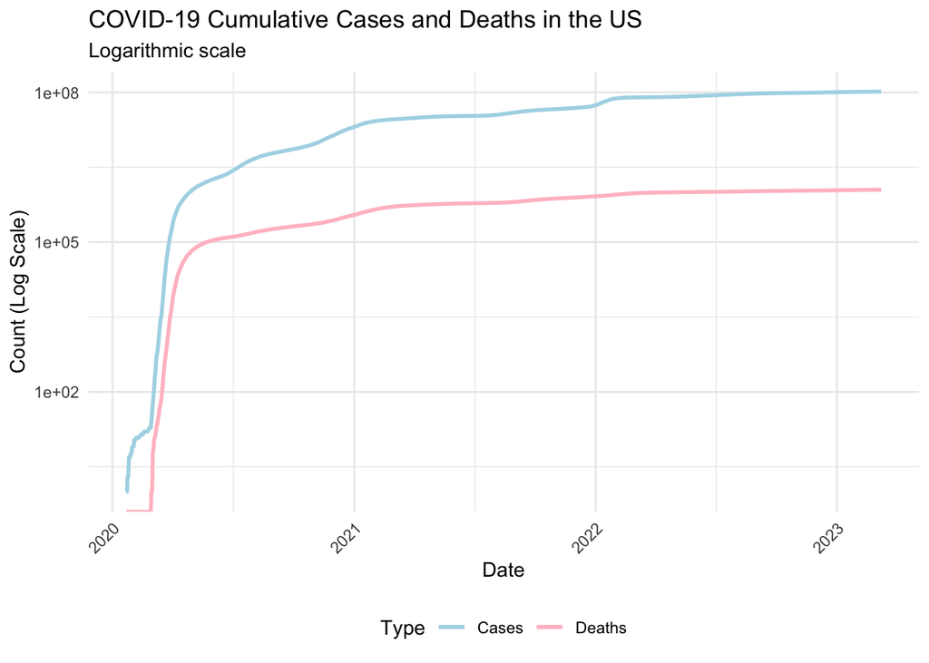

```r
# Plot cumulative cases and deaths over time
US_totals %>%
  ggplot(aes(x = date)) +
  geom_line(aes(y = cases, color = "Cases"), size = 1) +
  geom_line(aes(y = deaths, color = "Deaths"), size = 1) +
  scale_y_log10() +
  scale_color_manual(values = c("Cases" = "lightblue", "Deaths" = "pink")) +
  theme_minimal() +
  theme(legend.position = "bottom",
        axis.text.x = element_text(angle = 45, hjust = 1)) +
  labs(title = "COVID-19 Cumulative Cases and Deaths in the US",
       subtitle = "Logarithmic scale",
       x = "Date",
       y = "Count (Log Scale)",
       color = "Type")
```

### Plot State-Level: Arizona

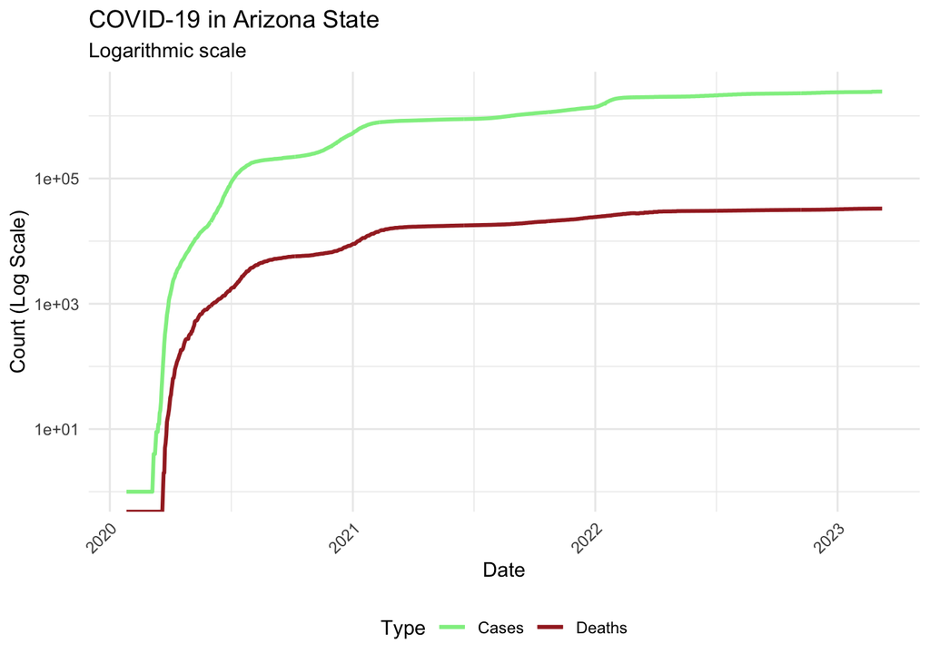

```r
# Example of state level, Arizona.
us_by_state %>%
  filter(Province_State == "Arizona") %>%
  filter(cases > 0) %>%
  ggplot(aes(x = date)) +
  geom_line(aes(y = cases, color = "Cases"), size = 1) +
  geom_line(aes(y = deaths, color = "Deaths"), size = 1) +
  scale_y_log10() +
  scale_color_manual(values = c("Cases" = "lightgreen", "Deaths" = "brown")) +
  theme_minimal() +
  theme(legend.position = "bottom",
        axis.text.x = element_text(angle = 45, hjust = 1)) +
  labs(title = "COVID-19 in Arizona State",
       subtitle = "Logarithmic scale",
       x = "Date",
       y = "Count (Log Scale)",
       color = "Type")
```

### Global Data Analysis: Top Contries

To fairly compare the confirmed cases and deaths of each country, we will be calculating the counts per thousand.

[figure not shown]

```r
# Prepare population lookup for counties
population_lookup <- population_data %>%
  group_by(country_region) %>%
  summarise(population = sum(Population, na.rm = TRUE))

# Summarize total cases and deaths by country with per thousand
cases_deaths_country <- global %>%
  group_by(country_region) %>%
  summarise(total_cases = max(cases, na.rm = TRUE),
            total_deaths = max(deaths, na.rm = TRUE)) %>%
  left_join(population_lookup, by = c("country_region" = "country_region")) %>%
  mutate(cases_per_1000 = (total_cases / population) * 1000,
         deaths_per_1000 = (total_deaths / population) * 1000) %>%
  filter(!is.na(cases_per_1000) & population > 0)

# Top 20 countries by cases per 1,000
top20_cases <- cases_deaths_country %>%
  arrange(desc(cases_per_1000)) %>%
  slice_head(n = 20)

# Plot: Cases per 1,000
ggplot(top20_cases, aes(x = reorder(country_region, cases_per_1000),
                        y = cases_per_1000)) +
  geom_col(fill = "lightblue", alpha = 0.7) +
  geom_text(aes(label = round(cases_per_1000, 1)),
            hjust = -0.1, size = 3) +
  coord_flip() +
  labs(title = "Top 10 Countries by COVID-19 Cases per 1,000 People",
       x = "Country",
       y = "Cases per 1,000 People") +
  theme_minimal()
```

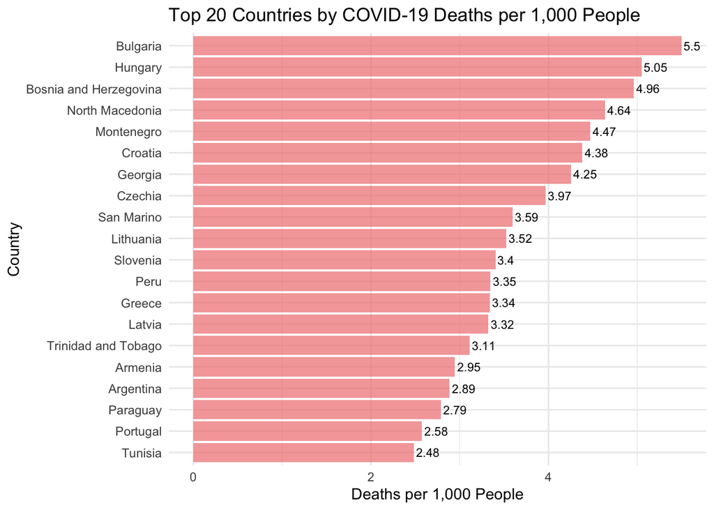

```r
# Top 20 countries by deaths per 1,000
top20_deaths <- cases_deaths_country %>%
  arrange(desc(deaths_per_1000)) %>%
  slice_head(n = 20)

# Plot: Deaths per 1,000
ggplot(top20_deaths, aes(x = reorder(country_region, deaths_per_1000),
                         y = deaths_per_1000)) +
  geom_col(fill = "lightcoral", alpha = 0.7) +
  geom_text(aes(label = round(deaths_per_1000, 2)),
            hjust = -0.1, size = 3) +
  coord_flip() +
  labs(title = "Top 20 Countries by COVID-19 Deaths per 1,000 People",
       x = "Country",
       y = "Deaths per 1,000 People") +
  theme_minimal()
```

### US State Analysis: Most and Least Affected

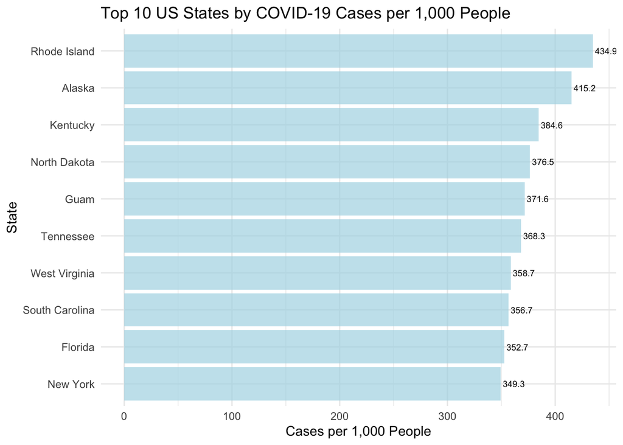

```r
# Calculate US state total counts per thousand people
us_state_totals <- us_by_state %>%
  group_by(Province_State) %>%
  summarise(deaths = max(deaths),
            cases = max(cases),
            Population = max(Population),
            cases_per_thou = 1000 * cases / Population,
            deaths_per_thou = 1000 * deaths / Population) %>%
  filter(cases > 0, Population > 0)

# Top 10 states with confirmed cases per  thousand
top_cases_states <- us_state_totals %>%
  slice_max(cases_per_thou, n = 10) %>%
  arrange(cases_per_thou)

# Plot
ggplot(top_cases_states, aes(x = reorder(Province_State, cases_per_thou),
                            y = cases_per_thou)) +
  geom_col(fill = "lightblue", alpha = 0.7) +
  geom_text(aes(label = round(cases_per_thou, 1)),
            hjust = -0.1, size = 2.5) +
  coord_flip() +
  labs(title = "Top 10 US States by COVID-19 Cases per 1,000 People",
       x = "State",
       y = "Cases per 1,000 People") +
  theme_minimal()
```

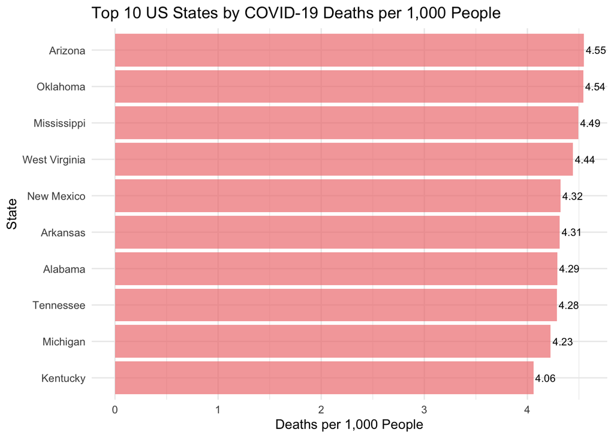

```r
# Select top 10 states by deaths per thousand
top_deaths_states <- us_state_totals %>%
  slice_max(deaths_per_thou, n = 10) %>%
  arrange(deaths_per_thou)

# Plot
ggplot(top_deaths_states, aes(x = reorder(Province_State, deaths_per_thou),
                             y = deaths_per_thou)) +
  geom_col(fill = "lightcoral", alpha = 0.7) +
  geom_text(aes(label = round(deaths_per_thou, 2)),
            hjust = -0.1, size = 3) +
  coord_flip() +
  labs(title = "Top 10 US States by COVID-19 Deaths per 1,000 People",
       x = "State",
       y = "Deaths per 1,000 People") +
  theme_minimal()
```

## Step 5: Statistical Analysis

### Correlation Between Case Rate and Death Rate

Let’s explore if there is a correlation between the case rate and death rate during the COVID-19 pandemic across the United States.

```r
# Let's create a linear model
model <- lm(deaths_per_thou ~ cases_per_thou, data = us_state_totals)
summary(model)
```

```
##
## Call:
## lm(formula = deaths_per_thou ~ cases_per_thou, data = us_state_totals)
##
## Residuals:
##     Min      1Q  Median      3Q     Max
## -2.3352 -0.5978  0.1491  0.6535  1.2086
##
## Coefficients:
##                Estimate Std. Error t value Pr(>|t|)
## (Intercept)    -0.36167    0.72480  -0.499     0.62
## cases_per_thou  0.01133    0.00232   4.881 9.76e-06 ***
## ---
## Signif. codes:  0 '***' 0.001 '**' 0.01 '*' 0.05 '.' 0.1 ' ' 1
##
## Residual standard error: 0.8615 on 54 degrees of freedom
## Multiple R-squared:  0.3061, Adjusted R-squared:  0.2933
## F-statistic: 23.82 on 1 and 54 DF,  p-value: 9.763e-06
```

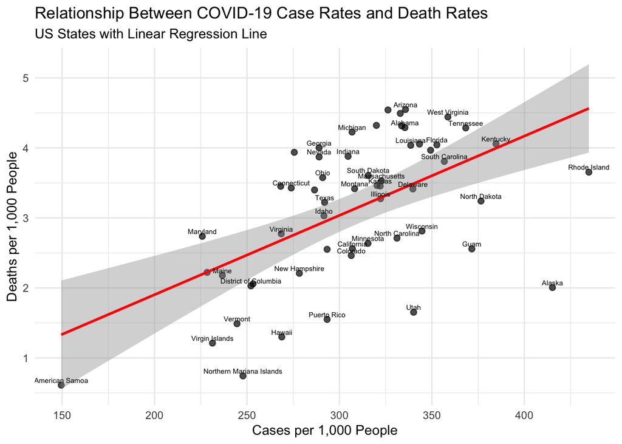

```r
# Lets's add the prediction to the data
us_state_totals_pred <- us_state_totals %>%
  mutate(predicted_deaths = predict(model))

# Let's create a scatter plot with a reggression line
ggplot(us_state_totals_pred, aes(x = cases_per_thou, y = deaths_per_thou)) +
  geom_point(alpha = 0.7, size = 2) +
  geom_smooth(method = "lm", se = TRUE, color = "red") +
  geom_text(aes(label = Province_State),
            vjust = -0.5, hjust = 0.5, size = 2, check_overlap = TRUE) +
  labs(title = "Relationship Between COVID-19 Case Rates and Death Rates",
       subtitle = "US States with Linear Regression Line",
       x = "Cases per 1,000 People",
       y = "Deaths per 1,000 People") +
  theme_minimal()
```

### Identifying Outliers

```r
# Let's calculate residuals to find outliers.
us_state_totals_pred <- us_state_totals_pred %>%
  mutate(residuals = deaths_per_thou - predicted_deaths)

# Find states with the largest positive residual, meaning had more deaths than predicted.
high_residual_states <- us_state_totals_pred %>%
  slice_max(residuals, n = 5) %>%
  select(Province_State, cases_per_thou, deaths_per_thou, predicted_deaths, residuals)

cat("States with Higher Death Rates than Predicted:\n")
```

```
## States with Higher Death Rates than Predicted:
```

```r
print(high_residual_states, digits = 2)
```

```
## # A tibble: 5 × 5
##   Province_State cases_per_thou deaths_per_thou predicted_deaths residuals
##   <chr>                   <dbl>           <dbl>            <dbl>     <dbl>
## 1 Oklahoma                 326.            4.54             3.33      1.21
## 2 Pennsylvania             276.            3.94             2.76      1.18
## 3 Michigan                 307.            4.23             3.11      1.11
## 4 Arizona                  336.            4.55             3.44      1.11
## 5 Georgia                  289.            4.00             2.91      1.09
```

```r
# Find states with the largest negative residual, meaning had less deaths than predicted.
low_residual_states <- us_state_totals_pred %>%
  slice_min(residuals, n = 5) %>%
  select(Province_State, cases_per_thou, deaths_per_thou, predicted_deaths, residuals)

cat("\nStates with Lower Death Rates than Predicted:\n")
```

```
##
## States with Lower Death Rates than Predicted:
```

```r
print(low_residual_states, digits = 2)
```

```
## # A tibble: 5 × 5
##   Province_State       cases_per_thou deaths_per_thou predicted_deaths residuals
##   <chr>                         <dbl>           <dbl>            <dbl>     <dbl>
## 1 Alaska                         415.           2.01              4.34     -2.34
## 2 Utah                           340.           1.65              3.49     -1.84
## 3 Northern Mariana Is…           248.           0.744             2.45     -1.70
## 4 Puerto Rico                    293.           1.55              2.96     -1.41
## 5 Hawaii                         269.           1.30              2.68     -1.38
```

## Conclusions

### Possible Factors to explain the variations among the stetes

- Healthcare system capacity
- Population demoghraphics
- population density
- Testing access
- Economic Factors

### Next Steps For Deeper Analysis

- Run a time series analysis to analyse trends over different phases during the pandemic
- Add population demographics to the analysis, like age, health history, and gender.
- Add and track how changes in policy during the pandemic affected the numbers.
- Add vaccination data and analyse its effect on the pandemic.